# FLicc user guide

## 14.2 Equilibrium curves and MSY proxies

```r
eqstk <- eqstklen(fit, s = 0.75)
eqstk@refpts
```

```
#> An object of class "FLPar"
#> params
#>   Fcur   Fspr   Ycur SSBcur SPRcur   SPR0
#> 0.2570 0.1114 0.5494 0.0579 0.1364 3.3226
#> units:  NA
```

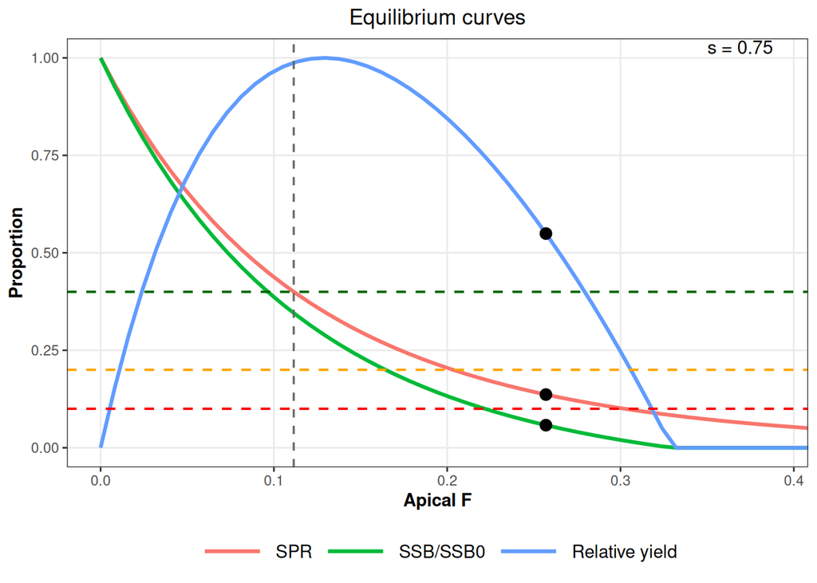

```r
plot_eqcurves(eqstk)
```

The same quantities without steepness, as per-recruit curves:

```r
prbrp <- prbrp_flicc(fit)
fmsy_flicc(prbrp, s = 0.75)
```

```
#> [1] 0.1296
```

```r
fspr_flicc(fit, spr = 35)
```

```
#> [1] 0.1285991
```

## 14.3 From SPR to relative spawning biomass

```r
round(spr2brel(c(0.2, 0.3, 0.4), s = 0.75, sprref = 40), 3)
```

```
#> [1] 0.368 0.684 1.000
```

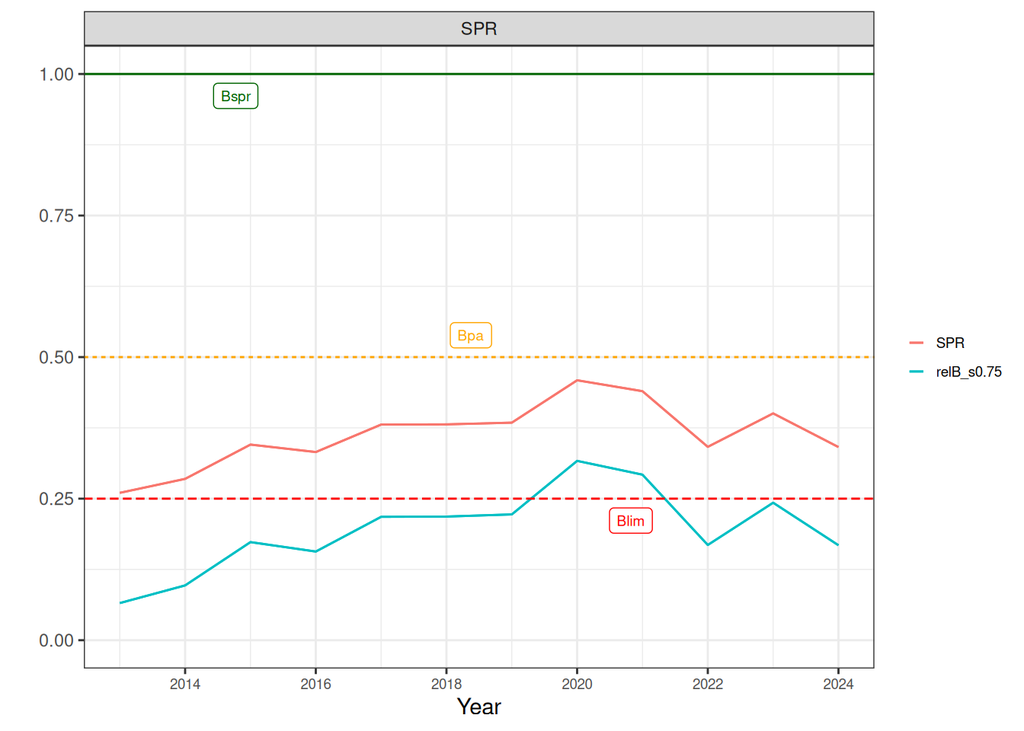

```r
plot_LBAdvice(FLStocks(SPR = flicc2FLStockR(fit, rel = TRUE),
                       relB_s0.75 = flicc2FLStockR(fit, rel = TRUE, s = 0.75)), panel = 1)
```

## 14.4 Stock status and advice plots

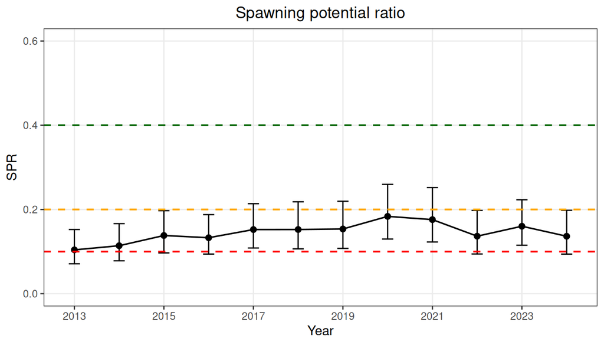

```r
plot_spr(fit, ci = TRUE)
```

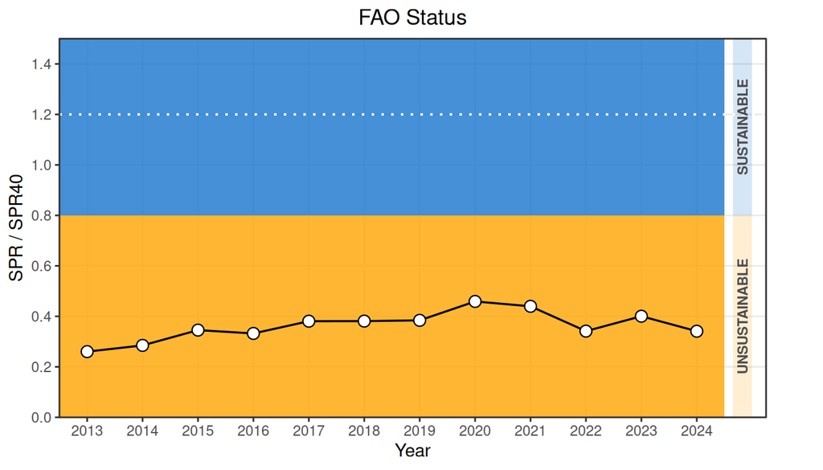

```r
plot_lbfao(fit)
```

`flicc2FLStockR()` converts the fit into an `FLStockR` object for advice plots: SPR (or $B/B_{tgt}$ with `s`) as the biomass indicator and F relative to Fspr, with reference points from the SPR target (`spr.btgt = 0.4`), `bpa` and `blim`:

```r
stk <- flicc2FLStockR(fit)
stk@refpts
```

```
#> An object of class "FLPar"
#> params
#>  Fspr  Bspr   Bpa  Blim
#> 0.111 0.400 0.200 0.100
#> units:  NA
```

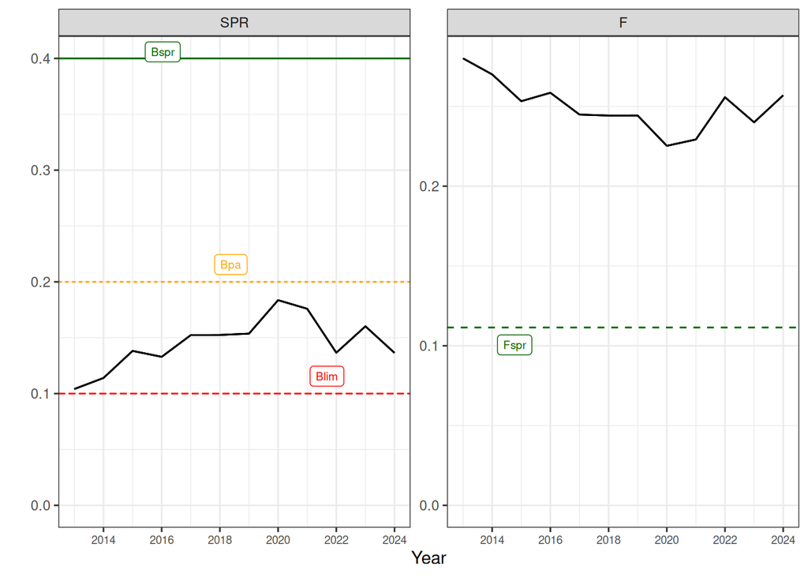

```r
plot_LBAdvice(stk)
```

With `rel = TRUE` the indicators are relative to the target (1 = at target), the usual form for advice:

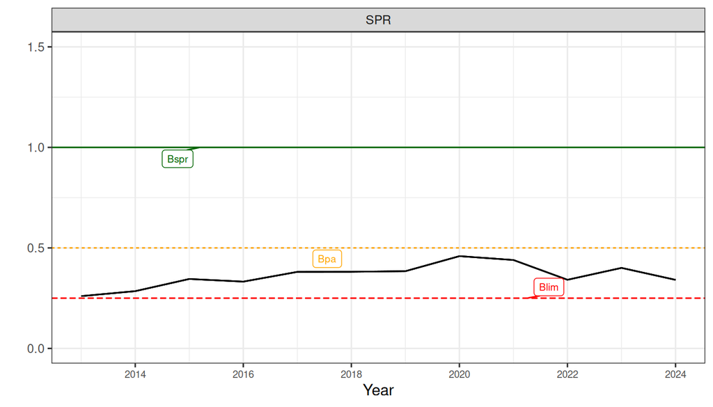

```r
stk_rel <- flicc2FLStockR(fit, rel = TRUE)
plot_LBAdvice(stk_rel, panels = 1) + ylim(0, 1.5)
```

`flicc_stklen(fit)` returns the fitted `FLStockLen` (numbers, catch and F at length by year) for further FLR workflows.

## 14.5 Status over F, selectivity and gear shares: contour plots

`contour_flicc()` computes yield per recruit and SPR over a grid, and `plot_contour_flicc()` draws one row per gear with yield on the left and spawning potential on the right. The grid can be laid out in three ways (`view`):

| `view` | x-axis | y-axis | other gears |
| --- | --- | --- | --- |
| `"fleet"` (default) | total F, F shares between gears as now | the gear’s `SL50` (logistic) or mode (dome) | F scaled with the total, selectivity as fitted |
| `"share"` | total F | the gear’s share of the total F (%) | the rest of the total F, in their current proportions |
| `"gear"` | the gear’s own F | the gear’s `SL50` or mode | current F and selectivity |

A change of selectivity shifts the gear’s curve along the length axis, keeping its shape. Yield is shown as % of its maximum over the grid (viridis colours); SPR in % on a scale anchored on the reference points: red below SPR 20%, orange to pale yellow between 20% and 40%, blue above 40%. The black lines are SPR 40% (solid) and 20% (dashed), the point is the current state, and the dotted horizontal line is the length at 50% maturity (Lmat).

The default view asks: if the whole fleet fished more or less, with the gears in their current proportions, and one gear changed its selectivity, what would yield and SPR be?

```r
cf <- contour_flicc(fit)
cf$current
```

```
#>            gear     type      loc         F       SPR       YPR    YPRrel
#> Trawl     Trawl dsnormal 17.78767 0.3351465 0.1364309 0.1292394 0.6854327
#> Gillnet Gillnet logistic 26.92765 0.3351465 0.1364309 0.1292394 0.9890687
#>            Fshare    Cshare
#> Trawl   0.7674952 0.6958661
#> Gillnet 0.2325048 0.3041339
```

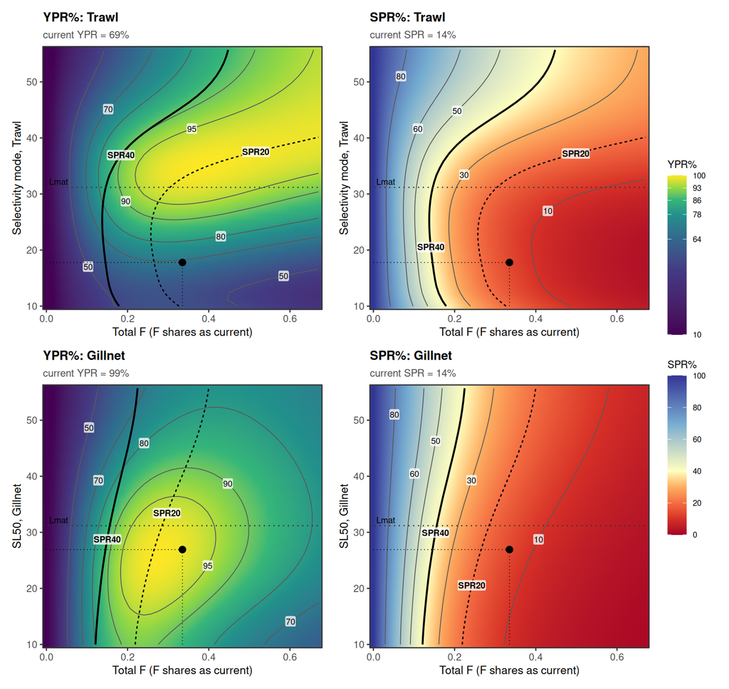

```r
plot_contour_flicc(cf)
```

The share view keeps all selectivities as fitted and asks how the split of F between gears matters. With two gears the two rows mirror each other, so one gear is enough. The subtitle gives the gear’s current share of F and of the catch; the two differ because the gears catch fish of different sizes.

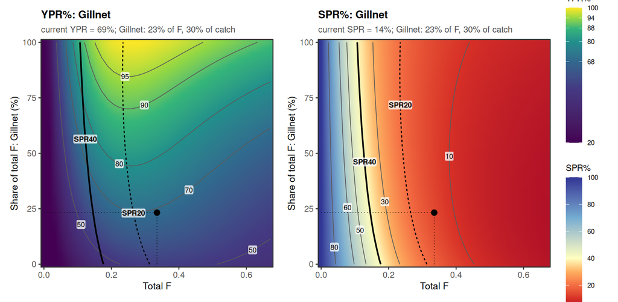

```r
cs <- contour_flicc(fit, view = "share", gear = "Gillnet")
plot_contour_flicc(cs)
```

In the `"gear"` view only one gear’s F changes; the other gears keep fishing at their current F, so at zero F of one gear the SPR reflects the other gear alone, and the catch split changes along the axis.

Per-recruit results assume constant recruitment. With a steepness `s`, the same surfaces are converted under a Beverton-Holt relationship to **SSB%** (spawning biomass in % of unfished, $B/B_0$) and **Yield%** (equilibrium yield in % of its maximum over the grid), with $R/R_0 = \frac{4s\,SPR - (1-s)}{(5s-1)\,SPR}$ and $B/B_0 = \frac{4s\,SPR - (1-s)}{5s-1}$. The black lines are then SSB 40% and 20%:

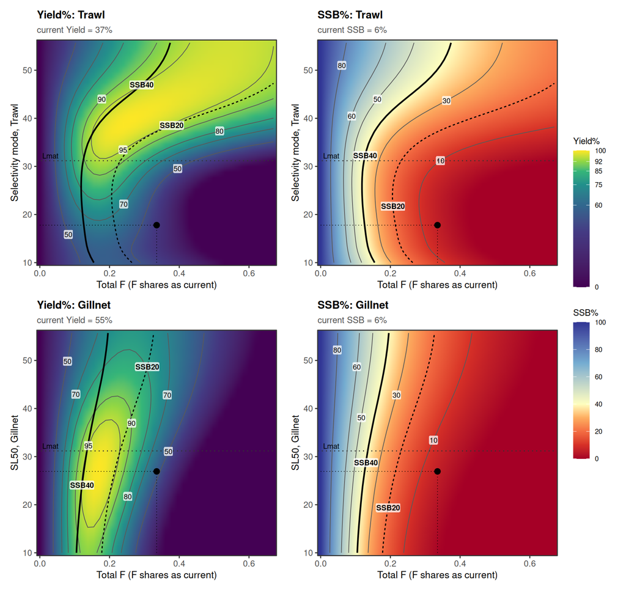

```r
plot_contour_flicc(cf, s = 0.75)
```

How to read them:

- Moving left (less F) or up (larger fish first caught) raises SPR; the yield isopleths show what that costs, or gains.
- Here the gillnet catches at `SL50` = 26.9 cm, below Lmat (31.2 cm). With all F as now, raising the gillnet `SL50` to Lmat gives an SPR of about 15% (now 14%) for a change in YPR of -1%; reaching SPR 40% at the current `SL50` by the gillnet alone needs its F cut by about more than 100%.
- Without `s` the surfaces are per-recruit results; with `s` they include the loss of recruitment at low spawning biomass, so yield falls off more steeply at high F. Both are equilibrium results at the fitted life history, a guide to direction and scale, not a forecast.

`gear =` selects gears (rows), `n` the grid resolution, `Fmax` and `Lrange` the axes, `ref` the reference levels (target, limit), and `levels`, `ylevels` the grey isopleths of the two columns.

# 15 Length-based indicators

## 15.1 LBIspr

For each gear, `LBIspr()` compares the observed proportion of large fish with the proportion expected at the reference $F_{\mathrm{SPR}x}$:

1. Equilibrium numbers-at-length at $F_{\mathrm{SPR}x}$, $N^{ref}(L)$, and the reference catch composition of gear $g$, $v_g(L) = N^{ref}(L) S_g(L)$ (retained bins only, i.e. below the tail cut).
2. Threshold length $L^*_g$: the length at which the cumulative $v_g$ reaches the fraction `thresh` (default 0.75) of its total.
3. Reference proportion above the threshold, $P^{ref}_g = \sum_{L \ge L^*_g} v_g(L) / \sum_L v_g(L)$ (about $1 -$ `thresh`).
4. Observed proportion in year $y$, $P^{obs}_{g,y} = \sum_{L \ge L^*_g} y_{g,y,L} / \sum_L y_{g,y,L}$.
5. Indicator $\mathrm{LBI}_{g,y} = P^{obs}_{g,y}/P^{ref}_g$.

$\mathrm{LBI} = 1$: as many large fish as at the target; $< 1$: fewer, i.e. F above $F_{\mathrm{SPR}x}$. The threshold lengths are returned as `attr(, "Lref")`.

```r
lbi <- LBIspr(fit, spr = 40, thresh = 0.75)
attr(lbi, "Lref")
```

```
#>   Trawl Gillnet
#>      23      38
```

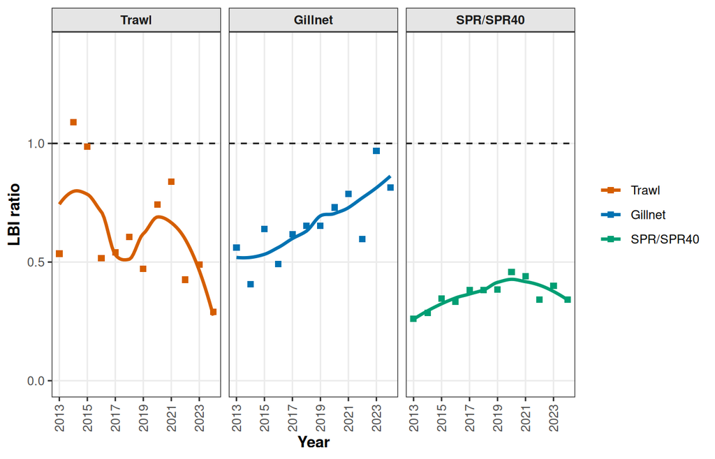

```r
plot_LBIspr(fit, thresh = 0.75)
```

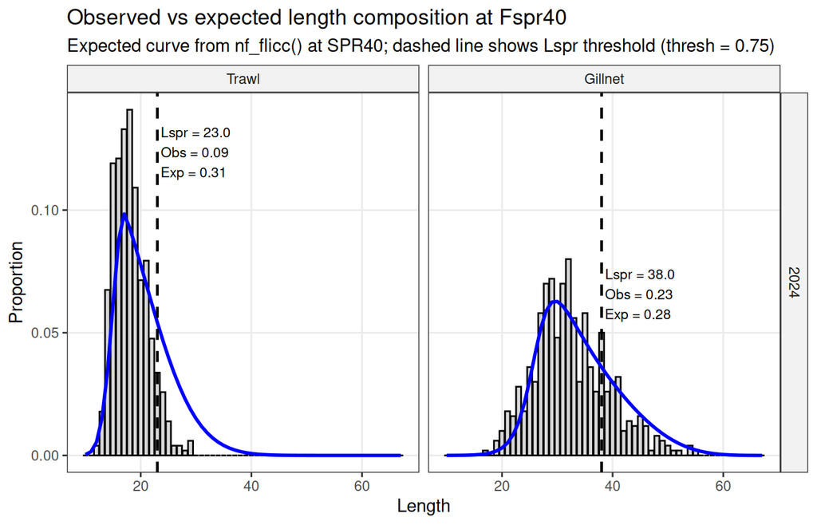

```r
plot_LBIp(fit, year = 2024)
```

## 15.2 LBImean

`LBImean()` is the model-based analogue of the ICES mean-length indicator $\bar L/L_{F=M}$: the reference mean length (above `lc`, default the gear’s 50% selectivity length) is computed from the fitted model at $F = M$ (`ref = "FM"`) or at $F_{\mathrm{SPR}x}$ (`ref = "spr"`), using the fitted growth variability and gear selectivity, including domes.

```r
LBImean(fit, ref = "FM")
```

```
#> An object of class "FLIndices"
#> [[1]]
#> An object of class "FLIndexBiomass"
#>
#> Name:
#> Description:
#> Distribution :
#> Quant: age
#> Dims:  age   year    unit    season  area    iter
#>  1   12  1   1   1   1
#>
#> Range:  min  max pgroup  minyear maxyear startf  endf
#>  NA  NA  NA  2013    2024    0.4 0.6
#>
#>
#> [[2]]
#> An object of class "FLIndexBiomass"
#>
#> Name:
#> Description:
#> Distribution :
#> Quant: age
#> Dims:  age   year    unit    season  area    iter
#>  1   12  1   1   1   1
#>
#> Range:  min  max pgroup  minyear maxyear startf  endf
#>  NA  NA  NA  2013    2024    0.4 0.6
#>
#>
#> Slot "names":
#> [1] "Trawl"   "Gillnet"
#>
#> Slot "desc":
#> character(0)
#>
#> Slot "lock":
#> [1] FALSE
```

## 15.3 Indicators and the tail cut

Both indicators use the fit’s tail cut by default (`tail_cut = NULL`), so the indicator and the likelihood use the same bins; `tail_cut = FALSE` uses all bins.

## 15.4 Check 10: indicators against status

| **Look for** | LBIspr and SPR/SPR40 telling the same story; similar indicators across gears. |
| --- | --- |
| **Red flags** | Gears disagreeing strongly (selectivity misfit or sampling); indicator noise much larger than the SPR trend. |
| **Action** | Use the more informative gear; pool gears (`pool` in `flicc.sa()`); smooth in the harvest control rule. |

# 16 Use in an MSE

`flicc.sa()` wraps `fiticc()` as the estimation step of an `mse` management procedure, with `lbi.hcr()`, `rfb.flicc.hcr()` and `flicc.is()` for the harvest control rule and implementation:

```r
est <- mseCtrl(method = flicc.sa, args = list(
  lhpar = lhpar, sel_fun = sel_fun, ess.g = 200,
  settings = list(obs_model = "dm", CVL = 0.1,
                  sigmaF = 0.3,      # fixed (or the F_re estimate from the real data)
                  tail_cut = 47,     # absolute length, the same in every iteration
                  spr_ref = 40),
  spr = 40))
```

- `se = FALSE` is used inside `flicc.sa()`; fixed sigmaF avoids its estimation in every year and iteration.
- The tail cut and sigmaF both trade responsiveness against stability; tune them together with the smoothing of the harvest control rule.
- Expect the equilibrium model to be pessimistic during a rebuild and optimistic while F increases.

# 17 Population and observation models compared

The population model (`gtg` or `gamma`) and the observation model (`mn`, `dm`, `nb`) can be combined freely. The four fits below differ only in these two settings; `Map()` runs one fit per list of settings.

```r
model_settings <- list(
  gtg_mn   = list(CVL = 0.1, pop_model = "gtg",   obs_model = "mn"),
  gtg_dm   = list(CVL = 0.1, pop_model = "gtg",   obs_model = "dm"),
  gtg_nb   = list(CVL = 0.1, pop_model = "gtg",   obs_model = "nb"),
  gamma_nb = list(CVL = 0.1, pop_model = "gamma", obs_model = "nb"))   # as fishblicc

fits_model <- Map(function(set) {
  fiticc(lfd200, stklen, sel_fun = sel_fun, catch_by_gear = cbg, settings = set)
}, model_settings)

data.frame(model    = names(fits_model),
           SPR_last = round(sapply(fits_model, sprcur_flicc), 3),
           se_log   = round(sapply(fits_model, se_logspr), 3),
           row.names = NULL)
```

```
#>      model SPR_last se_log
#> 1   gtg_mn    0.104  0.155
#> 2   gtg_dm    0.136  0.190
#> 3   gtg_nb    0.104  0.155
#> 4 gamma_nb    0.100  0.155
```

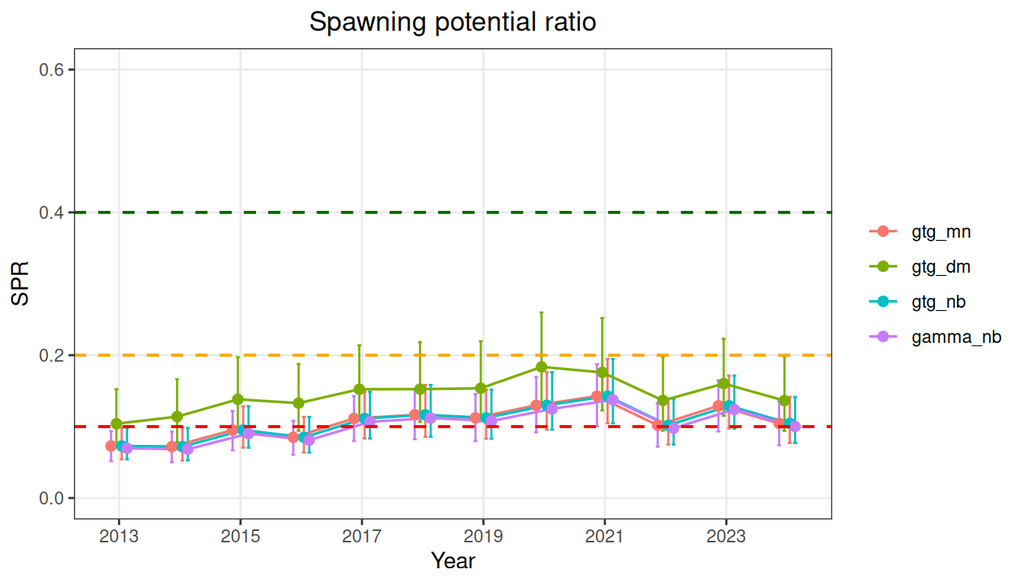

```r
plot_spr(fits_model, ci = TRUE)
```

The gamma model integrates over Linf numerically and is slower:

```r
system.time(fiticc(lfd200, stklen, sel_fun = sel_fun, catch_by_gear = cbg,
                   settings = model_settings$gtg_nb))
```

```
#>    user  system elapsed
#>   0.659   0.000   0.659
```

```r
system.time(fiticc(lfd200, stklen, sel_fun = sel_fun, catch_by_gear = cbg,
                   settings = model_settings$gamma_nb))
```

```
#>    user  system elapsed
#>  10.078   0.072  10.152
```

Log-likelihoods and AIC are not comparable between observation models (they are likelihoods of different things); compare the estimates, their precision and the fit to the compositions (`plot_len`). Differences between `gtg` and `gamma` show the sensitivity to the approximation of growth variability, differences between `mn`, `dm` and `nb` the weight and robustness given to the compositions.

| Purpose | `pop_model` | `obs_model` | Comment |
| --- | --- | --- | --- |
| Routine assessment, MSE | `"gtg"` | `"dm"` | fast; robust with real data |
| LBSPR-style | `"gtg"` | `"mn"` | fastest; sensitive to the ESS |
| fishblicc replication | `"gamma"` | `"nb"` | slower; closest to fishblicc |

# 18 Reproducing fishblicc: the Bombay duck example

FLicc includes the Bombay duck example of fishblicc (three gears) to check consistency with fishblicc. Natural mortality decreases with length (`m_model = "inverse"`, $M(L) = M\, L_{ref} / L$ with $L_{ref} = 21.9$), and Linf, M/k and CVL are estimated with priors as in fishblicc:

```r
data("fishblicc_example")
lhpar_fishblicc <- rbind(lhpar_fishblicc,
                         FLPar(M = lhpar_fishblicc["k"] * lhpar_fishblicc["Mk"]))
stklen_fishblicc <- stocklen(lfd_fishblicc, lhpar_fishblicc,
                             m_model = "inverse", reflen = 21.9)
```

```r
fit_fishblicc <- fiticc(lfd_fishblicc, stklen_fishblicc,
                        sel_fun = c("dsnormal", "dsnormal", "dsnormal"),
                        catch_by_gear = c(0.1802070, 0.2101353, 0.6096577),
                        settings = list(pop_model = "gamma", obs_model = "nb",
                                        CVL = 0.14, CVL.sd = 0.1,
                                        linf.sd = 2 / 40, Mk.sd = 0.1))
flicc_convergence(fit_fishblicc)
```

```
#>                              check              value passed
#> 2           Gradient is acceptable           0.001648   TRUE
#> 3     Hessian is positive definite               TRUE   TRUE
#> 4        Standard errors available 16 / 16 parameters   TRUE
#> 5 Hessian eigenvalues are positive               8.59   TRUE
#>                                            interpretation
#> 2                 The fit is close to a stationary point.
#> 3                    The model curvature is well behaved.
#> 4      Uncertainty could be estimated for all parameters.
#> 5 No flat or negative curvature directions were detected.
```

```r
sprcur_flicc(fit_fishblicc)
```

```
#> [1] 0.2908798
```

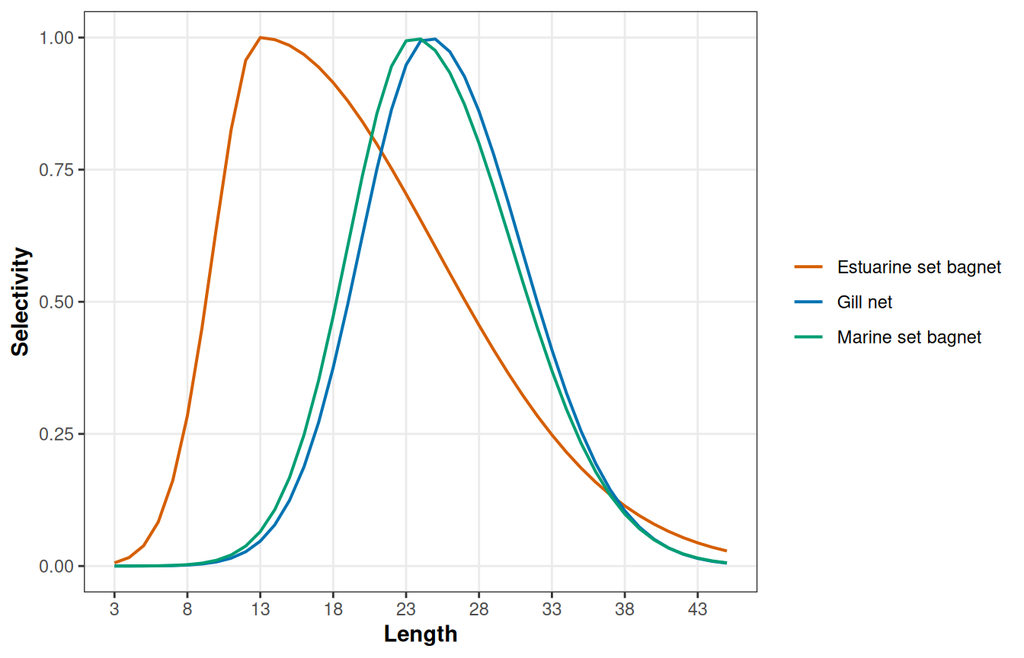

```r
plot_sel(fit_fishblicc)
```

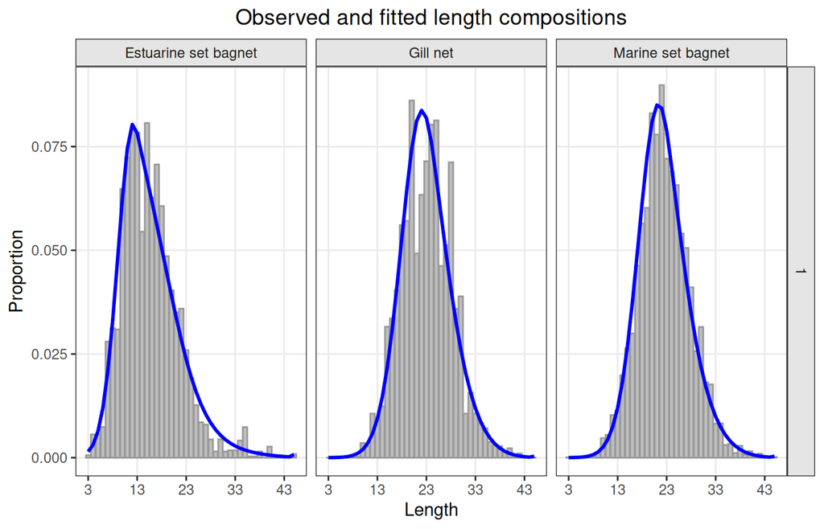

```r
plot_len(fit_fishblicc, by_gear = TRUE)
```

```r
eqstk_fishblicc <- eqstklen(fit_fishblicc, s = 0.7)
eqstk_fishblicc@refpts
```

```
#> An object of class "FLPar"
#> params
#>   Fcur   Fspr   Ycur SSBcur SPRcur   SPR0
#>  1.194  0.867  0.871  0.206  0.291  1.395
#> units:  NA
```

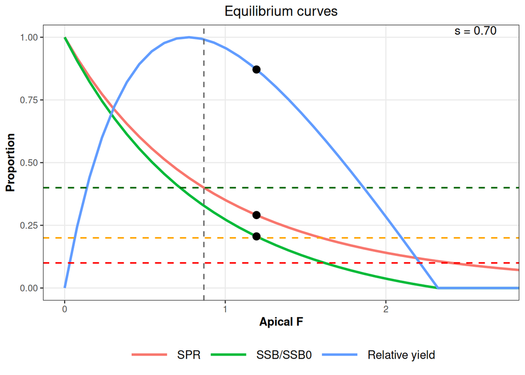

```r
plot_eqcurves(eqstk_fishblicc)
```

# 19 Summary of checks and recommendations

| # | Check | Red flag | Action |
| --- | --- | --- | --- |
| 1 | sample size by gear-year (`plot_lfdn`) | < 50 fish or < 10 bins; gear mix changing | ESS per gear; drop/pool poor gear-years |
| 2 | composition consistency (`plot_lfd`) | shifts in mode or left limb | split gears/periods; restrict years |
| 3 | largest fish vs Linf | > 1% at or above Linf | revisit Linf; tail cut |
| 4 | empirical catch curves (`plot_zlcc`) | curved limbs, jumping slopes | dome or tail cut; keep random walk |
| 5 | life-history inputs | Linf inconsistent with data; odd M/k | Linf sensitivity; priors (`linf.sd`) as a check |
| 6 | selectivity plausibility (`plot_sel`) | narrow or unsupported domes | logistic; fix from external data; dome sensitivity (`dome_sens_flicc`) |
| 7 | convergence (`flicc_convergence`) | gradient, Hessian, bounds | restarts; simplify; tail cut |
| 8 | fit to compositions (`plot_len`, `plot_resid_bubble`, `lmean_resid_flicc`, `ppc_flicc`) | systematic misfit; failed runs test; many values outside predictive intervals | selectivity, Linf, tail cut; lower ESS; cohort patterns are expected |
| 9 | retrospective | rho beyond ±0.2 | trends in selectivity or sampling |
| 10 | indicators vs status | gears disagree | best gear; pooling; HCR smoothing |

| Topic | Recommendation |
| --- | --- |
| Observation model | `dm` with real data |
| Sample size | ESS about 150-200 per gear-year; never raw thousands |
| Growth | fix Linf and CVL; Linf is the main sensitivity; `maxsd = 3` as sensitivity |
| Selectivity | logistic unless supported; always run `dome_sens_flicc()` (rsd 1000 to 0.25 x Linf) |
| Management options | `plot_contour_flicc()`: yield and SPR (or SSB with `s`) over selectivity and F by gear |
| F over time | random walk, sigmaF fixed (0.3 or the `F_re` estimate); `by_year = TRUE` only as a check |
| Tail | `tail_cut` at about 0.80-0.85 x Linf, as a length |
| Missing data | keep zeros, rely on the random walk; not without random walk |
| Status | SPR at the year’s F; `s` for $B/B_{tgt}$ under Beverton-Holt; `plot_LBAdvice(flicc2FLStockR(fit))` |
| Models | `gtg` + `dm` routinely; `gamma` + `nb` to replicate fishblicc |
| MSE | fixed sigmaF, absolute tail cut, `se = FALSE`; tune with the HCR |

*Planned: a worked example of a rebuilding stock, refitted year by year, to show how SPR, the tail cut and sigmaF respond over time; estimated Dirichlet-multinomial overdispersion.*